# Aprendizaje no supervisado: Trade&Ahead

### Puntuaciones de silueta

```
For n_clusters = 2, the silhouette score is 0.43969639509980457)
For n_clusters = 3, the silhouette score is 0.4644405674779404)
For n_clusters = 4, the silhouette score is 0.45434371948348606)
For n_clusters = 5, the silhouette score is 0.43169988466492354)
For n_clusters = 6, the silhouette score is 0.36698524210914063)
For n_clusters = 7, the silhouette score is 0.10587349598463779)
For n_clusters = 8, the silhouette score is 0.40021596082234684)
For n_clusters = 9, the silhouette score is 0.4051539505522535)
For n_clusters = 10, the silhouette score is 0.1147132918355368)
For n_clusters = 11, the silhouette score is 0.16268826704862685)
For n_clusters = 12, the silhouette score is 0.12883008320005324)
For n_clusters = 13, the silhouette score is 0.1744804713048242)
For n_clusters = 14, the silhouette score is 0.17597674098501367)
```

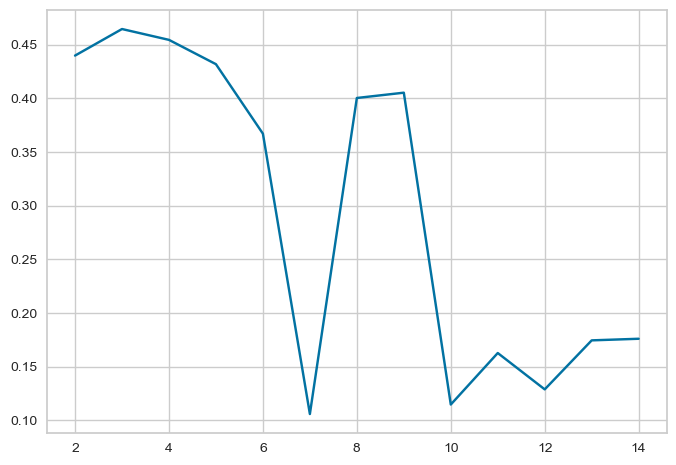

```
CPU times: total: 33 s
Wall time: 16.4 s
```

```python
%%time
sil_score = []
cluster_list = range(2, 15)
for n_clusters in cluster_list:
    clusterer = KMeans(n_clusters=n_clusters, random_state=1)
    preds = clusterer.fit_predict((subset_scaled_df))
    score = silhouette_score(k_means_df, preds)
    sil_score.append(score)
    print("For n_clusters = {}, the silhouette score is {})".format(n_clusters, score))

plt.plot(cluster_list, sil_score)
plt.show()
```

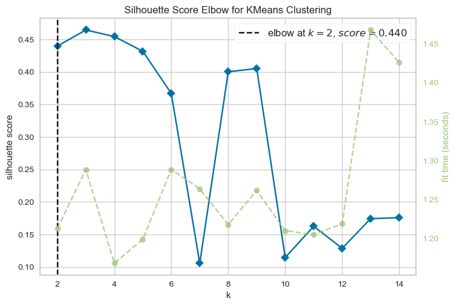

```python
model = KMeans(random_state=1)
visualizer = KElbowVisualizer(model, k=(2, 15), metric="silhouette", timings=True)
visualizer.fit(k_means_df)  # fit the data to the visualizer
visualizer.show()  # finalize and render figure
```

Esto me indica que, aunque inicialmente me inclinaba por 7 clústeres basándome en el método del codo, los puntajes de silueta sugieren que un menor número de clústeres podría ser preferible. En particular, k=3 también presenta un puntaje de silueta alto, y los tiempos de ajuste no son excesivamente diferentes a medida que k aumenta. Por tanto, voy a ponderar entre k=2 y k=3 para mi agrupación final, considerando que estos ofrecen una buena separación de los datos con una eficiencia de cálculo razonable.

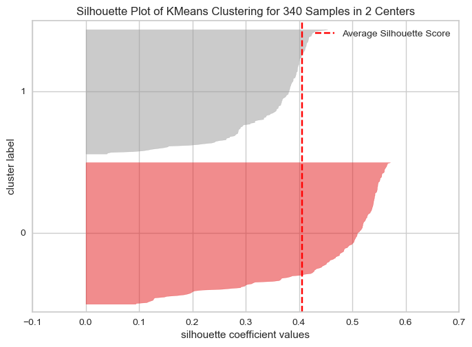

```python
# finding optimal no. of clusters with silhouette coefficients
visualizer = SilhouetteVisualizer(KMeans(2, random_state=1))
visualizer.fit(k_means_df)
visualizer.show()
```

La amplia área de color rojo sugiere que los puntos en su mayoría tienen valores positivos de coeficiente de silueta, lo que es una buena señal de que los clústeres están bien separados y son cohesivos. Sin embargo, la presencia de cualquier valor de silueta por debajo de cero (lo cual no se observa en este gráfico) indicaría puntos que podrían haber sido asignados al clúster incorrecto.

En resumen, este gráfico de silueta respalda la elección de 2 clústeres, mostrando una agrupación clara y consistente.

### Modelo Final

```python
# final K-means model
kmeans = KMeans(n_clusters=2, random_state=1)
kmeans.fit(k_means_df)
```

```
KMeans(n_clusters=2, random_state=1)
```

```python
# creating a copy of the original data
df1 = df.copy()

# adding kmeans cluster labels to the original and scaled dataframes
k_means_df["KM_segments"] = kmeans.labels_
df1["KM_segments"] = kmeans.labels_
```

### Perfiles cluster

```python
km_cluster_profile = df1.groupby("KM_segments").mean()
```

```python
km_cluster_profile["count_in_each_segment"] = (
    df1.groupby("KM_segments")["Security"].count().values
)
```

```python
km_cluster_profile.style.highlight_max(color="lightgreen", axis=0)
```

| KM_segments | Current Price | Price Change | Volatility | ROE | Cash Ratio | Net Cash Flow | Net Income | Earnings Per Share | Estimated Shares Outstanding | P/E Ratio | P/B Ratio | count_in_each_segment |
| --- | --- | --- | --- | --- | --- | --- | --- | --- | --- | --- | --- | --- |
| 0 | 86.518786 | 10.868452 | 1.390003 | 28.077348 | 88.182320 | -115890397.790055 | 2570442729.281768 | 4.016630 | 772259591.830000 | 27.092464 | 0.086587 | 181 |
| 1 | 74.423251 | -3.651598 | 1.680764 | 52.710692 | 49.352201 | 250685238.993711 | 269437930.817610 | 1.365126 | 354783954.183270 | 38.896450 | -3.772812 | 159 |

```python
for cl in df1["KM_segments"].unique():
    print("In cluster {}, the following companies are present:".format(cl))
    print(df1[df1["KM_segments"] == cl]["Security"].unique())
    print()
```

```
In cluster 0, the following companies are present:
['American Airlines Group' 'AbbVie' 'Abbott Laboratories'
 'Adobe Systems Inc' 'Analog Devices, Inc.' 'Alliance Data Systems'
 'AFLAC Inc' 'American International Group, Inc.'
 'Apartment Investment & Mgmt' 'Albemarle Corp' 'Allstate Corp'
 'Applied Materials Inc' 'Amgen Inc' 'American Tower Corp A'
 'Amphenol Corp' 'Activision Blizzard' 'AvalonBay Communities, Inc.'
 'Broadcom' 'American Water Works Company Inc' 'Boeing Company'
 'Baxter International Inc.' 'BB&T Corporation' 'BIOGEN IDEC Inc.'
 'The Bank of New York Mellon Corp.' 'Ball Corp' 'Bristol-Myers Squibb'
 'Boston Scientific' 'Boston Properties' 'Citigroup Inc.'
 'Caterpillar Inc.' 'Chubb Limited' 'CBRE Group'
 'Crown Castle International Corp.' 'Carnival Corp.' 'Celgene Corp.'
 'Citizens Financial Group' 'CIGNA Corp.' 'Cincinnati Financial'
 'Chipotle Mexican Grill' 'Centene Corporation' 'Citrix Systems'
 'CVS Health' 'Chevron Corp.' 'Delta Air Lines' 'Du Pont (E.I.)'
 'Deere & Co.' 'Discover Financial Services' 'Quest Diagnostics'
 'Danaher Corp.' 'The Walt Disney Company' 'Delphi Automotive'
 'Digital Realty Trust' 'Dover Corp.' 'Dr Pepper Snapple Group'
 'eBay Inc.' 'Equifax Inc.' 'Equinix' 'Equity Residential'
 'Essex Property Trust, Inc.' 'E*Trade' 'Edwards Lifesciences'
 'Extra Space Storage' 'Ford Motor' 'Fastenal Co' 'Facebook'
 'Fortune Brands Home & Security' 'Fluor Corp.' 'FMC Corporation'
 'Federal Realty Investment Trust' 'First Solar Inc'
 'Frontier Communications' 'Gilead Sciences' 'Corning Inc.'
 'General Motors' 'Goodyear Tire & Rubber' 'Huntington Bancshares'
 "Honeywell Int'l Inc." 'Hormel Foods Corp.' 'Henry Schein'
 'Host Hotels & Resorts' 'International Business Machines'
 'Intl Flavors & Fragrances' 'Interpublic Group' 'Intuitive Surgical Inc.'
 'Illinois Tool Works' 'Invesco Ltd.' 'Jacobs Engineering Group'
 'Juniper Networks' 'JPMorgan Chase & Co.' 'Kimco Realty'
 'Coca Cola Company' 'Laboratory Corp. of America Holding'
 'L-3 Communications Holdings' 'Lilly (Eli) & Co.' 'Lockheed Martin Corp.'
 'Southwest Airlines' 'Level 3 Communications' 'LyondellBasell'
 'Mastercard Inc.' 'Mid-America Apartments' 'Masco Corp.' 'Mattel Inc.'
 "McDonald's Corp." "Moody's Corp" 'Mondelez International' 'MetLife Inc.'
 'Mead Johnson' 'McCormick & Co.' 'Marsh & McLennan' '3M Company'
 'Monster Beverage' 'Altria Group Inc' 'Marathon Petroleum' 'Merck & Co.'
 'Mettler Toledo' 'Mylan N.V.' 'NASDAQ OMX Group' 'NextEra Energy'
 'Newmont Mining Corp. (Hldg. Co.)' 'Norfolk Southern Corp.' 'Nucor Corp.'
```

[output cut: 55 more lines]

```
 'Nielsen Holdings' 'National Oilwell Varco Inc.' 'Northern Trust Corp.'
 'ONEOK' "O'Reilly Automotive" 'Occidental Petroleum'
 "People's United Financial" 'Pitney-Bowes' 'PACCAR Inc.' 'PG&E Corp.'
 'Priceline.com Inc' 'Public Serv. Enterprise Inc.'
 'Principal Financial Group' 'Pulte Homes Inc.' 'Pentair Ltd.'
 'Pinnacle West Capital' 'PPL Corp.' 'Quanta Services Inc.' 'Praxair Inc.'
 'Ryder System' 'Robert Half International' 'Range Resources Corp.'
 'Spectra Energy Corp.' 'Sealed Air' 'S&P Global, Inc.' 'Stericycle Inc'
 'Sempra Energy' 'State Street Corp.' 'Skyworks Solutions'
 'Southwestern Energy' 'Synchrony Financial' 'Stryker Corp.'
 'Teradata Corp.' 'Torchmark Corp.' 'Tractor Supply Company'
 'Under Armour' 'Universal Health Services, Inc.' 'Unum Group'
 'Union Pacific' 'Verisk Analytics' 'Ventas Inc' 'Wec Energy Group Inc'
 'Whirlpool Corp.' 'Williams Cos.' 'Western Union Co' 'Wyndham Worldwide'
 'Cimarex Energy' 'Xcel Energy Inc' 'Yum! Brands Inc' 'Zions Bancorp']
```

```python
df1.groupby(["KM_segments", "GICS Sector"])['Security'].count()
```

```
KM_segments  GICS Sector
0            Consumer Discretionary         17
             Consumer Staples               14
             Energy                          6
             Financials                     26
             Health Care                    30
             Industrials                    27
             Information Technology         21
             Materials                      11
             Real Estate                    21
             Telecommunications Services     4
             Utilities                       4
1            Consumer Discretionary         23
             Consumer Staples                5
             Energy                         24
             Financials                     23
             Health Care                    10
             Industrials                    26
             Information Technology         12
             Materials                       9
             Real Estate                     6
             Telecommunications Services     1
             Utilities                      20
Name: Security, dtype: int64
```

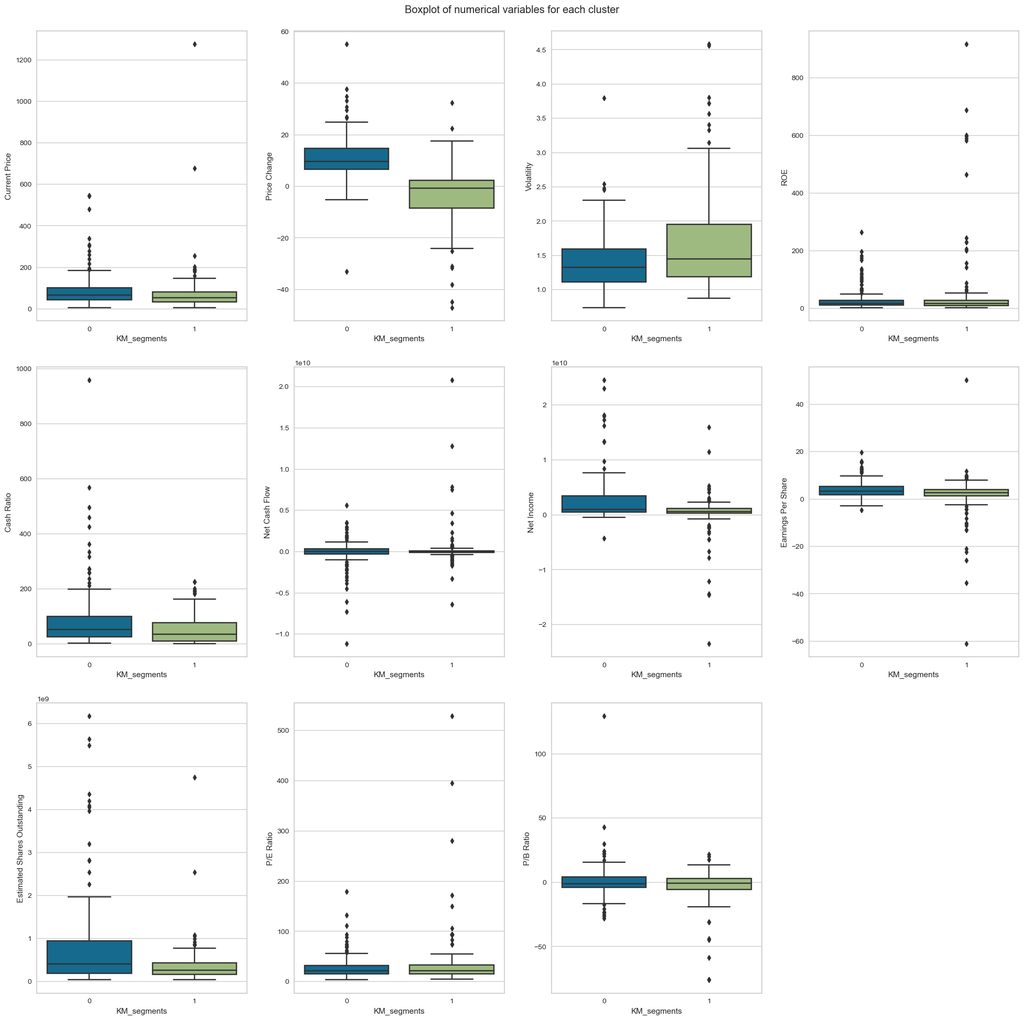

```python
plt.figure(figsize=(20, 20))
plt.suptitle("Boxplot of numerical variables for each cluster")

# selecting numerical columns
num_col = df.select_dtypes(include=np.number).columns.tolist()

for i, variable in enumerate(num_col):
    plt.subplot(3, 4, i + 1)
    sns.boxplot(data=df1, x="KM_segments", y=variable)

plt.tight_layout(pad=2.0)
```

## Agrupación jerárquica

### Correlacion Cofenetica

```python
hc_df = subset_scaled_df.copy()
```

```python
%%time
# list of distance metrics
distance_metrics = ["euclidean", "chebyshev", "mahalanobis", "cityblock"]

# list of linkage methods
linkage_methods = ["single", "complete", "average", "weighted"]

high_cophenet_corr = 0
high_dm_lm = [0, 0]

for dm in distance_metrics:
    for lm in linkage_methods:
        Z = linkage(hc_df, metric=dm, method=lm)
        c, coph_dists = cophenet(Z, pdist(hc_df))
        print(
            "Cophenetic correlation for {} distance and {} linkage is {}.".format(
                dm.capitalize(), lm, c
            )
        )
        if high_cophenet_corr < c:
            high_cophenet_corr = c
            high_dm_lm[0] = dm
            high_dm_lm[1] = lm

# printing the combination of distance metric and linkage method with the highest cophenetic correlation
print('*'*100)
print(
    "Highest cophenetic correlation is {}, which is obtained with {} distance and {} linkage.".format(
        high_cophenet_corr, high_dm_lm[0].capitalize(), high_dm_lm[1]
    )
)
```

```
Cophenetic correlation for Euclidean distance and single linkage is 0.9232271494002922.
Cophenetic correlation for Euclidean distance and complete linkage is 0.7873280186580672.
Cophenetic correlation for Euclidean distance and average linkage is 0.9422540609560814.
Cophenetic correlation for Euclidean distance and weighted linkage is 0.8693784298129404.
Cophenetic correlation for Chebyshev distance and single linkage is 0.9062538164750717.
Cophenetic correlation for Chebyshev distance and complete linkage is 0.598891419111242.
Cophenetic correlation for Chebyshev distance and average linkage is 0.9338265528030499.
Cophenetic correlation for Chebyshev distance and weighted linkage is 0.9127355892367.
Cophenetic correlation for Mahalanobis distance and single linkage is 0.9259195530524591.
Cophenetic correlation for Mahalanobis distance and complete linkage is 0.7925307202850002.
Cophenetic correlation for Mahalanobis distance and average linkage is 0.9247324030159737.
Cophenetic correlation for Mahalanobis distance and weighted linkage is 0.8708317490180428.
Cophenetic correlation for Cityblock distance and single linkage is 0.9334186366528574.
Cophenetic correlation for Cityblock distance and complete linkage is 0.7375328863205818.
Cophenetic correlation for Cityblock distance and average linkage is 0.9302145048594667.
Cophenetic correlation for Cityblock distance and weighted linkage is 0.731045513520281.
Highest cophenetic correlation is 0.9422540609560814, which is obtained with Euclidean distance and average linkage.
CPU times: total: 312 ms
Wall time: 180 ms
```

La correlación cofenética más alta de 0.9422540609560814 se obtiene con la distancia Euclidiana y el enlace promedio (average linkage). Esto indica que esta combinación es particularmente buena para capturar la estructura de los datos en este caso.

```python
%%time
# list of linkage methods
linkage_methods = ["single", "complete", "average", "centroid", "ward", "weighted"]

high_cophenet_corr = 0
high_dm_lm = [0, 0]

for lm in linkage_methods:
    Z = linkage(hc_df, metric="euclidean", method=lm)
    c, coph_dists = cophenet(Z, pdist(hc_df))
    print("Cophenetic correlation for {} linkage is {}.".format(lm, c))
    if high_cophenet_corr < c:
        high_cophenet_corr = c
        high_dm_lm[0] = "euclidean"
        high_dm_lm[1] = lm

# printing the combination of distance metric and linkage method with the highest cophenetic correlation
print('*'*100)
print(
    "Highest cophenetic correlation is {}, which is obtained with {} linkage.".format(
        high_cophenet_corr, high_dm_lm[1]
    )
)
```

```
Cophenetic correlation for single linkage is 0.9232271494002922.
Cophenetic correlation for complete linkage is 0.7873280186580672.
Cophenetic correlation for average linkage is 0.9422540609560814.
Cophenetic correlation for centroid linkage is 0.9314012446828154.
Cophenetic correlation for ward linkage is 0.7101180299865353.
Cophenetic correlation for weighted linkage is 0.8693784298129404.
Highest cophenetic correlation is 0.9422540609560814, which is obtained with average linkage.
CPU times: total: 31.2 ms
Wall time: 50.9 ms
```

Podemos observar que el enlace promedio proporciona la representación más fiel de las distancias entre las observaciones en el conjunto de datos original, con una correlación cofenética de 0.9422540609560814. Este resultado destaca la eficacia del enlace promedio en la preservación de la estructura de los datos, lo que sugiere que es la mejor opción entre las metodologías que probé para este análisis específico.

### Comprobacion de dendogramas

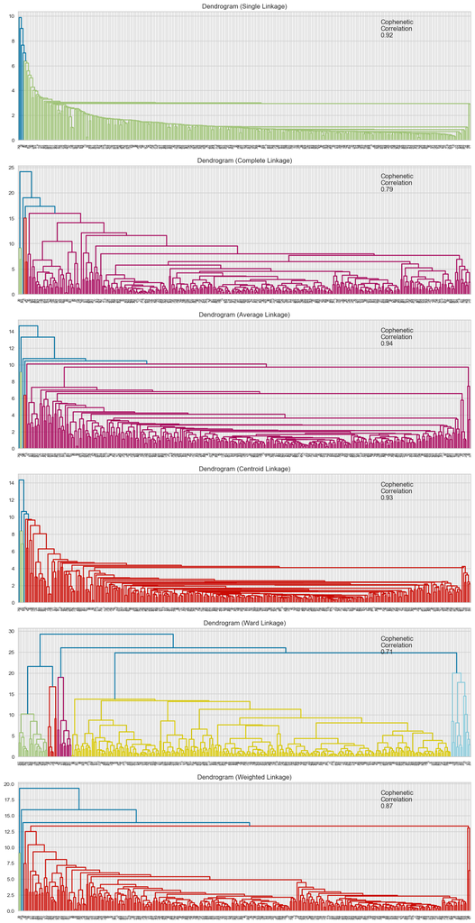

```python
# list of linkage methods
linkage_methods = ["single", "complete", "average", "centroid", "ward", "weighted"]
# lists to save results of cophenetic correlation calculation
compare_cols = ["Linkage", "Cophenetic Coefficient"]
compare = []

# to create a subplot image
fig, axs = plt.subplots(len(linkage_methods), 1, figsize=(15, 30))

# We will enumerate through the list of linkage methods above
# For each linkage method, we will plot the dendrogram and calculate the cophenetic correlation
for i, method in enumerate(linkage_methods):
    Z = linkage(hc_df, metric="euclidean", method=method)

    dendrogram(Z, ax=axs[i])
    axs[i].set_title(f"Dendrogram ({method.capitalize()} Linkage)")

    coph_corr, coph_dist = cophenet(Z, pdist(hc_df))
    axs[i].annotate(
        f"Cophenetic\nCorrelation\n{coph_corr:0.2f}",
        (0.80, 0.80),
        xycoords="axes fraction",
    )

    compare.append([method, coph_corr])
```

```python
df_cc = pd.DataFrame(compare, columns=compare_cols)
df_cc = df_cc.sort_values(by="Cophenetic Coefficient")
df_cc
```

|  | Linkage | Cophenetic Coefficient |
| --- | --- | --- |
| 4 | ward | 0.710118 |
| 1 | complete | 0.787328 |
| 5 | weighted | 0.869378 |
| 0 | single | 0.923227 |
| 3 | centroid | 0.931401 |
| 2 | average | 0.942254 |

Al examinar el dendrograma producido utilizando el método de enlace de Ward, se puede observar una clara separación entre los distintos grupos. A pesar de que la correlación cofenética de 0.71 no es la más alta que se ha obtenido, esta medida sigue siendo relativamente fuerte, indicando que el dendrograma de Ward conserva bien las distancias entre las muestras. Sin embargo, más allá de la correlación cofenética, la elección de utilizar el método de enlace de Ward se justifica por su habilidad para identificar grupos que son internamente homogéneos.

El enlace de Ward minimiza la suma de las diferencias cuadradas dentro de todos los clústeres. Es decir, este método tiende a crear clústeres más equilibrados y es particularmente útil cuando los clústeres están en aproximadamente la misma escala. Esto se puede apreciar en el dendrograma, donde los colores representan diferentes niveles de agrupación. La estructura del dendrograma con enlace de Ward muestra una separación clara que sugiere un número óptimo de cinco clústeres para este conjunto de datos. Esta separación es indicativa de que los grupos formados serán distintos y bien definidos.

Por tanto, a pesar de que otras medidas de enlace podrían proporcionar una correlación cofenética más alta, el enlace de Ward es elegido por su eficacia en la creación de grupos cohesivos y bien diferenciados, lo cual es esencial para el objetivo de nuestro análisis: obtener una segmentación significativa y utilizable de los datos. La decisión de elegir cinco clústeres se basa en la observación visual del dendrograma, donde se puede identificar un punto natural para 'cortar' el dendrograma y así obtener grupos con suficiente separación entre ellos, manteniendo al mismo tiempo un grado de similitud dentro de cada grupo.

### Creacion del modelo

```python
HCmodel = AgglomerativeClustering(n_clusters=5, affinity='euclidean', linkage='ward')
HCmodel.fit(hc_df)
```

```
AgglomerativeClustering(affinity='euclidean', n_clusters=5)
```

```python
# creating a copy of the original data
df2 = df.copy()

# adding hierarchical cluster labels to the original and scaled dataframes
hc_df["HC_segments"] = HCmodel.labels_
df2["HC_segments"] = HCmodel.labels_
```

### Perfiles Cluster

```python
hc_cluster_profile = df2.groupby("HC_segments").mean()
```

```python
hc_cluster_profile["count_in_each_segment"] = (
    df2.groupby("HC_segments")["Security"].count().values
)
```

```python
hc_cluster_profile.style.highlight_max(color="lightgreen", axis=0)
```

| HC_segments | Current Price | Price Change | Volatility | ROE | Cash Ratio | Net Cash Flow | Net Income | Earnings Per Share | Estimated Shares Outstanding | P/E Ratio | P/B Ratio | count_in_each_segment |
| --- | --- | --- | --- | --- | --- | --- | --- | --- | --- | --- | --- | --- |
| 0 | 326.198218 | 10.563242 | 1.642560 | 14.400000 | 309.466667 | 288850666.666667 | 864498533.333333 | 7.785333 | 544900261.301333 | 113.095334 | 19.142151 | 15 |
| 1 | 84.355716 | 3.854981 | 1.827670 | 633.571429 | 33.571429 | -568400000.000000 | -4968157142.857142 | -10.841429 | 398169036.442857 | 42.284541 | -11.589502 | 7 |
| 2 | 42.848182 | 6.270446 | 1.123547 | 22.727273 | 71.454545 | 558636363.636364 | 14631272727.272728 | 3.410000 | 4242572567.290909 | 15.242169 | -4.924615 | 11 |
| 3 | 72.760400 | 5.213307 | 1.427078 | 25.603509 | 60.392982 | 79951512.280702 | 1538594322.807018 | 3.655351 | 446472132.228456 | 24.722670 | -2.647194 | 285 |
| 4 | 36.440455 | -16.073408 | 2.832884 | 57.500000 | 42.409091 | -472834090.909091 | -3161045227.272727 | -8.005000 | 514367806.201818 | 85.555682 | 0.836839 | 22 |

```python
for cl in df2["HC_segments"].unique():
    print("In cluster {}, the following companies are present:".format(cl))
    print(df2[df2["HC_segments"] == cl]["Security"].unique())
    print()
```

```
In cluster 3, the following companies are present:
['American Airlines Group' 'AbbVie' 'Abbott Laboratories'
 'Adobe Systems Inc' 'Analog Devices, Inc.' 'Archer-Daniels-Midland Co'
 'Ameren Corp' 'American Electric Power' 'AFLAC Inc'
 'American International Group, Inc.' 'Apartment Investment & Mgmt'
 'Assurant Inc' 'Arthur J. Gallagher & Co.' 'Akamai Technologies Inc'
 'Albemarle Corp' 'Alaska Air Group Inc' 'Allstate Corp'
 'Applied Materials Inc' 'AMETEK Inc' 'Affiliated Managers Group Inc'
 'Ameriprise Financial' 'American Tower Corp A' 'AutoNation Inc'
 'Anthem Inc.' 'Aon plc' 'Amphenol Corp' 'Arconic Inc'
 'Activision Blizzard' 'AvalonBay Communities, Inc.' 'Broadcom'
 'American Water Works Company Inc' 'American Express Co' 'Boeing Company'
 'Baxter International Inc.' 'BB&T Corporation' 'Bard (C.R.) Inc.'
 'BIOGEN IDEC Inc.' 'The Bank of New York Mellon Corp.' 'Ball Corp'
 'Bristol-Myers Squibb' 'Boston Scientific' 'BorgWarner'
 'Boston Properties' 'Caterpillar Inc.' 'Chubb Limited' 'CBRE Group'
 'Crown Castle International Corp.' 'Carnival Corp.' 'Celgene Corp.'
 'CF Industries Holdings Inc' 'Citizens Financial Group' 'Church & Dwight'
 'C. H. Robinson Worldwide' 'CIGNA Corp.' 'Cincinnati Financial'
 'Comerica Inc.' 'CME Group Inc.' 'Cummins Inc.' 'CMS Energy'
 'Centene Corporation' 'CenterPoint Energy' 'Capital One Financial'
 'The Cooper Companies' 'CSX Corp.' 'CenturyLink Inc'
 'Cognizant Technology Solutions' 'Citrix Systems' 'CVS Health'
 'Chevron Corp.' 'Dominion Resources' 'Delta Air Lines' 'Du Pont (E.I.)'
 'Deere & Co.' 'Discover Financial Services' 'Quest Diagnostics'
 'Danaher Corp.' 'The Walt Disney Company' 'Discovery Communications-A'
 'Discovery Communications-C' 'Delphi Automotive' 'Digital Realty Trust'
 'Dun & Bradstreet' 'Dover Corp.' 'Dr Pepper Snapple Group' 'Duke Energy'
 'DaVita Inc.' 'eBay Inc.' 'Ecolab Inc.' 'Consolidated Edison'
 'Equifax Inc.' "Edison Int'l" 'Eastman Chemical' 'Equity Residential'
 'EQT Corporation' 'Eversource Energy' 'Essex Property Trust, Inc.'
 'E*Trade' 'Eaton Corporation' 'Entergy Corp.' 'Edwards Lifesciences'
 'Exelon Corp.' "Expeditors Int'l" 'Expedia Inc.' 'Extra Space Storage'
 'Fastenal Co' 'Fortune Brands Home & Security' 'FirstEnergy Corp'
 'Fidelity National Information Services' 'Fiserv Inc' 'FLIR Systems'
 'Fluor Corp.' 'Flowserve Corporation' 'FMC Corporation'
 'Federal Realty Investment Trust' 'First Solar Inc' 'General Dynamics'
 'General Growth Properties Inc.' 'Gilead Sciences' 'Corning Inc.'
 'General Motors' 'Genuine Parts' 'Garmin Ltd.' 'Goodyear Tire & Rubber'
 'Grainger (W.W.) Inc.' 'Halliburton Co.' 'Hasbro Inc.'
```

[output cut: 61 more lines]

```
 'S&P Global, Inc.']

In cluster 4, the following companies are present:
['Anadarko Petroleum Corp' 'Baker Hughes Inc' 'Cabot Oil & Gas'
 'Concho Resources' 'Devon Energy Corp.' 'EOG Resources'
 'Freeport-McMoran Cp & Gld' 'Hess Corporation' 'Kinder Morgan'
 'Marathon Oil Corp.' 'Murphy Oil' 'Noble Energy Inc'
 'Newfield Exploration Co' 'National Oilwell Varco Inc.' 'ONEOK'
 'Occidental Petroleum' 'Range Resources Corp.' 'Spectra Energy Corp.'
 'Southwestern Energy' 'Teradata Corp.' 'Williams Cos.' 'Cimarex Energy']

In cluster 2, the following companies are present:
['Bank of America Corp' 'Citigroup Inc.' 'Ford Motor' 'Intel Corp.'
 'JPMorgan Chase & Co.' 'Coca Cola Company' 'Pfizer Inc.' 'AT&T Inc'
 'Verizon Communications' 'Wells Fargo' 'Exxon Mobil Corp.']
```

```python
df2.groupby(["HC_segments", "GICS Sector"])['Security'].count()
```

```
HC_segments  GICS Sector
0            Consumer Discretionary          3
             Consumer Staples                1
             Health Care                     5
             Information Technology          4
             Real Estate                     1
             Telecommunications Services     1
1            Consumer Discretionary          1
             Consumer Staples                2
             Energy                          2
             Financials                      1
             Industrials                     1
2            Consumer Discretionary          1
             Consumer Staples                1
             Energy                          1
             Financials                      4
             Health Care                     1
             Information Technology          1
             Telecommunications Services     2
3            Consumer Discretionary         35
             Consumer Staples               15
             Energy                          7
             Financials                     44
             Health Care                    34
             Industrials                    52
             Information Technology         27
             Materials                      19
             Real Estate                    26
             Telecommunications Services     2
             Utilities                      24
4            Energy                         20
             Information Technology          1
             Materials                       1
Name: Security, dtype: int64
```

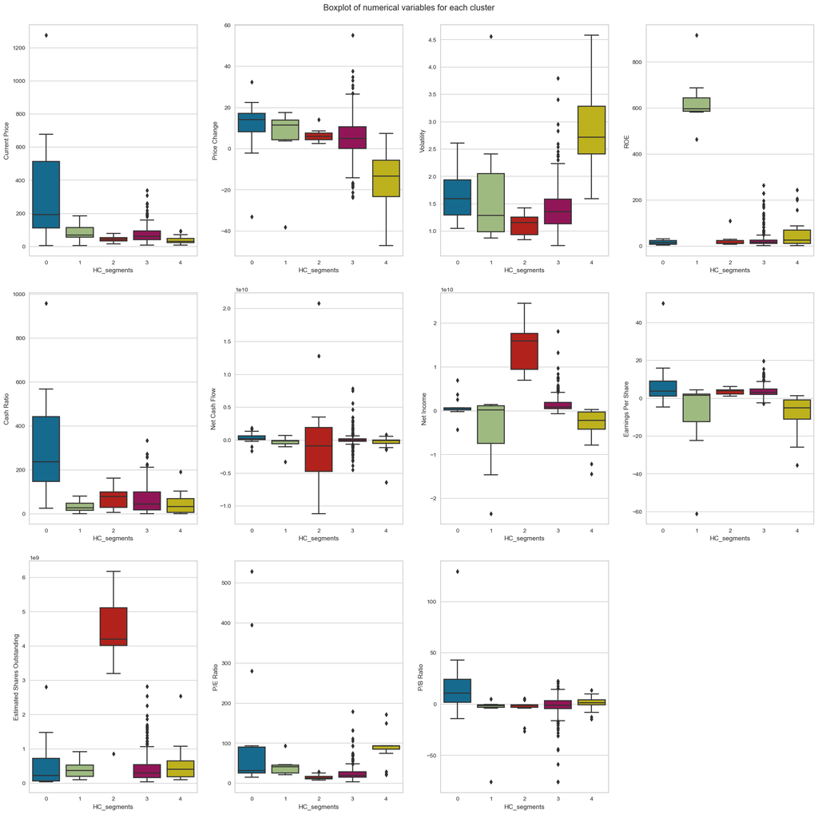

```python
plt.figure(figsize=(20, 20))
plt.suptitle("Boxplot of numerical variables for each cluster")

for i, variable in enumerate(num_col):
    plt.subplot(3, 4, i + 1)
    sns.boxplot(data=df2, x="HC_segments", y=variable)

plt.tight_layout(pad=2.0)
```

### Perspectivas

Cluster 3: Con un ingreso neto y ganancias por acción relativamente altos, este cluster puede representar empresas rentables con una sólida generación de ingresos y eficiencia en la rentabilidad.

### Recomendaciones y estrategias:

Cluster 0:

Estrategia: Inversión a largo plazo en empresas establecidas.

Justificación: Estas empresas tienen precios de acciones altos y cambios de precios positivos, lo que podría indicar una sólida posición en el mercado y potencial de crecimiento sostenido.

Aplicación Práctica: Trade&Ahead podría recomendar estas acciones para inversores que buscan seguridad y crecimiento con una visión a largo plazo.

Cluster 1:

Cluster 2:

Estrategia: Inversión en empresas con rendimientos financieros consistentes.

Aplicación Práctica: Ideal para inversores que buscan una combinación equilibrada de crecimiento y estabilidad.

Cluster 3:

Estrategia: Enfoque en empresas con alta rentabilidad y eficiencia.

Justificación: Las empresas con un alto Net Income y Earnings Per Share son atractivas por su capacidad de generar ganancias y su eficiencia operativa.

Aplicación Práctica: Pueden ser adecuadas para clientes que buscan empresas con potencial de reinversión y crecimiento agresivo.

Cluster 4:

Estrategia: Oportunidades de inversión en empresas con precios recientemente ajustados.

Aplicación Práctica: Trade&Ahead podría asesorar a los clientes para que aprovechen estas situaciones de mercado, siempre que el análisis fundamental respalde la inversión.

## K-means vs Agrupamiento jerárquico

Comparas varias cosas, como:

- ¿Qué técnica de agrupamiento tardó menos en ejecutarse? En mi caso, K-Means tardo más en ejecutarse que la agrupacion jerarquica.
- ¿Qué técnica de agrupamiento le dio más agrupaciones distintas, o son lo mismo? En mi caso, la tecnica que más agrupaciones me dio fue la de agrupacion jerarquica.
- ¿Cuántas observaciones hay en los conglomerados similares de ambos algoritmos? Al ejecutar ambas tecnicas podemos ver que no hay una cantidad de observaciones similares en los conglomerados.
- ¿Cuántos clústeres se obtienen como el número apropiado de clústeres de ambos algoritmos? Para K-means el numero apropiado que encontre fue de 2 centroides y para agrupacion jerarquica fue de 5.

## Información práctica y recomendaciones

En base a los resultados de clustering obtenidos a través de técnicas de K-Means y clustering jerárquico, y considerando las métricas financieras proporcionadas para las empresas que cotizan en la Bolsa de Nueva York, puedo ofrecer las siguientes recomendaciones prácticas y observaciones útiles para Trade&Ahead y sus estrategias de inversión personalizadas:

Segmentación de Empresas para Diversificación de Cartera:

Los clusters formados por K-Means y clustering jerárquico han revelado patrones distintos en las características financieras de las empresas. Utilizar estos segmentos permite una diversificación más estratégica de la cartera, ya que cada cluster representa un perfil de riesgo y oportunidad diferente.

Estrategias de Inversión Basadas en Clusters:

Para los clusters que muestran un alto precio actual de las acciones y cambios positivos en el precio, como el Cluster 0 en el resultado de K-Means, recomendaría una estrategia de inversión centrada en el crecimiento a largo plazo y en la captura de la apreciación del capital. Los clusters con un Cash Ratio alto y cambios de precio más estables serían adecuados para inversores conservadores interesados en la estabilidad y la generación de ingresos por dividendos.

Identificación de Oportunidades de Compra:

Los clusters que presentan una disminución en el precio de las acciones, como el Cluster 4 en el resultado de clustering jerárquico, podrían revelar oportunidades de compra para inversores dispuestos a asumir un riesgo calculado. Sin embargo, estas oportunidades requieren un análisis fundamental adicional para asegurar que la disminución del precio no se deba a problemas estructurales de la empresa. Vigilancia de Valores Atípicos:

Los valores atípicos identificados en los gráficos de caja pueden representar oportunidades únicas de inversión o alertar sobre posibles riesgos. Es esencial investigar estos casos individualmente para comprender su desviación de las tendencias generales del cluster.

Ajuste de la Estrategia Según el Mercado:

Las estrategias de inversión deben ser flexibles y ajustarse en respuesta a las condiciones cambiantes del mercado. La segmentación basada en el clustering puede necesitar una revisión periódica para alinearla con las últimas tendencias económicas y de mercado.

Educación del Cliente:

Es crucial comunicar a los clientes las razones detrás de la selección de clusters y cómo cada segmento se alinea con sus objetivos de inversión. Esto fomenta la confianza y ayuda a los clientes a comprender las decisiones de inversión.

Aplicación de Tecnología de Datos:

Continuaré empleando técnicas avanzadas de ciencia de datos y aprendizaje automático para refinar los modelos de clustering y mejorar la precisión de las estrategias de inversión que ofrecemos a nuestros clientes.

En conclusión, la aplicación de análisis de clustering en el mercado de valores es una herramienta poderosa que nos permite identificar patrones que de otro modo serían difíciles de discernir. Al adoptar un enfoque basado en datos, Trade&Ahead puede proporcionar a sus clientes estrategias de inversión que no solo son personalizadas sino también dinámicas y respaldadas por un análisis exhaustivo.